# Task 2 : Prediction using Supervised ML

Shalini Kumari

12/10/2020

In this task , we are predicting the percentage of marks of students based on the number of study hours . This is a simple linear regression task.

First , importing necessary libraries.

```r
# Libraries
library(tidyverse)
```

```r
library(caTools)
library(ggplot2)
library(e1071)
```

Now , importing dataset

```r
# Importing Dataset
Hours_data <- read.csv("Task_2.csv")
Hours_data
```

```
##    Hours Scores
## 1    2.5     21
## 2    5.1     47
## 3    3.2     27
## 4    8.5     75
## 5    3.5     30
## 6    1.5     20
## 7    9.2     88
## 8    5.5     60
## 9    8.3     81
## 10   2.7     25
## 11   7.7     85
## 12   5.9     62
## 13   4.5     41
## 14   3.3     42
## 15   1.1     17
## 16   8.9     95
## 17   2.5     30
## 18   1.9     24
## 19   6.1     67
## 20   7.4     69
## 21   2.7     30
## 22   4.8     54
## 23   3.8     35
## 24   6.9     76
## 25   7.8     86
```

It is good practice to analyze and understand the variables. We will graphically analyse the data . The following plots are drawn to visualize the following behavior .

*Scatter Plot : Visulize the linear relationship between the predictor and response.

*Box Plot : To spot any outlier observations in the variable .

*Density Plot : To see the distribution of the predictor variable. It will check if the response variable is close to normality.

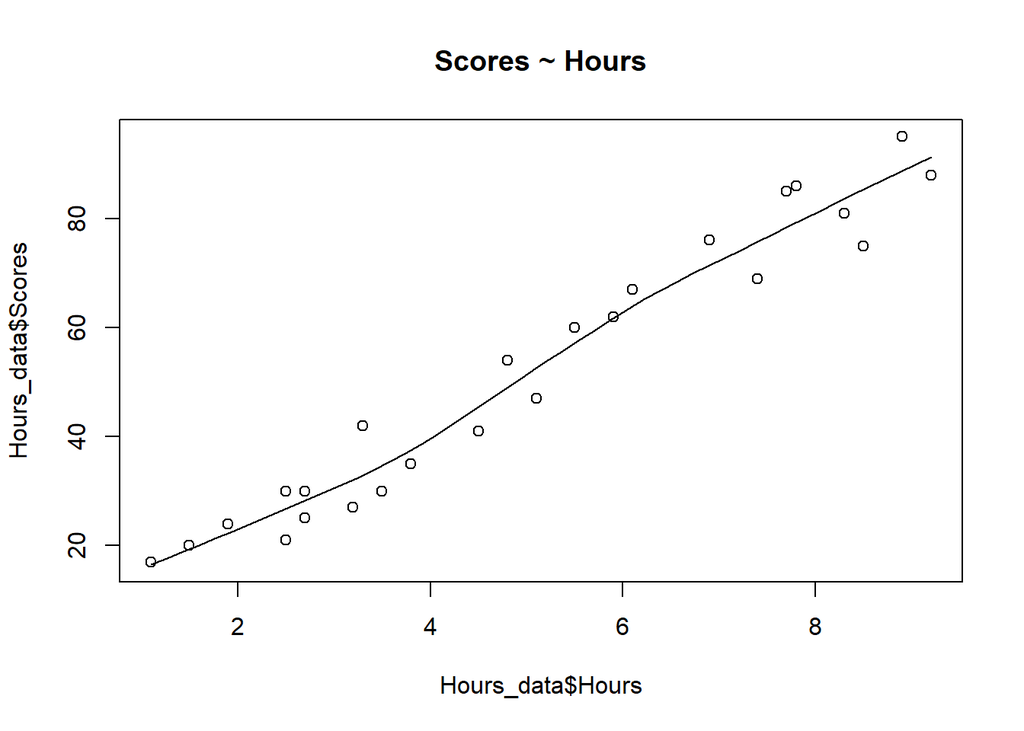

```r
# Graphical Analysis

# Scatter Plot

scatter.smooth(x =Hours_data$Hours , y = Hours_data$Scores , main = "Scores ~ Hours" )
```

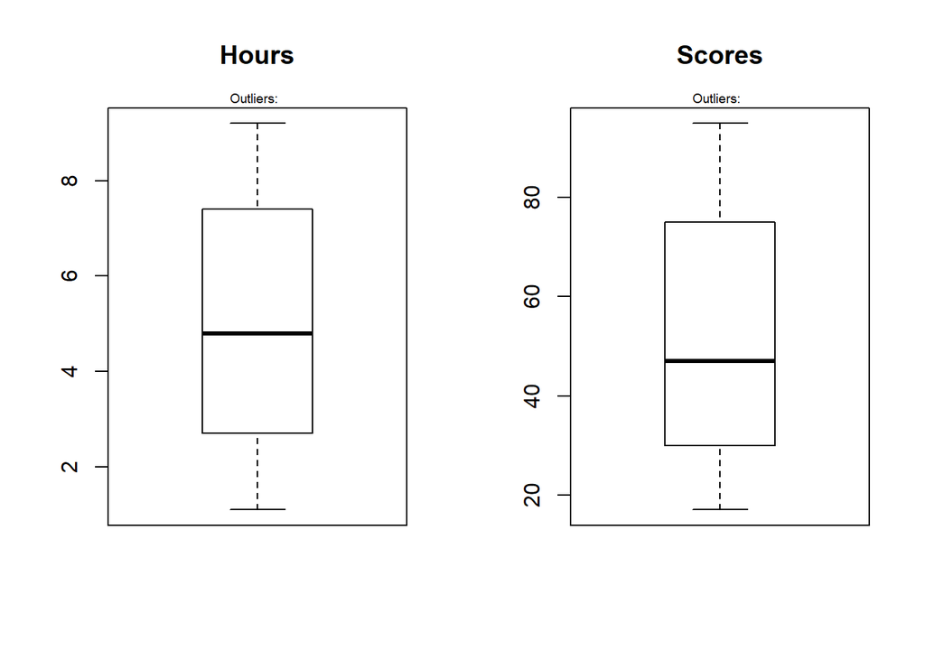

```r
# Box Plot

par(mfrow = c(1,2))
outlier_values <- boxplot.stats(Hours_data$Hours)$out
boxplot(Hours_data$Hours , main = "Hours" )
mtext(paste("Outliers: ", paste(outlier_values, collapse=", ")), cex=0.6)
outlier_values <- boxplot.stats(Hours_data$Scores)$out
boxplot(Hours_data$Scores , main = "Scores" )
mtext(paste("Outliers: ", paste(outlier_values, collapse=", ")), cex=0.6)
```

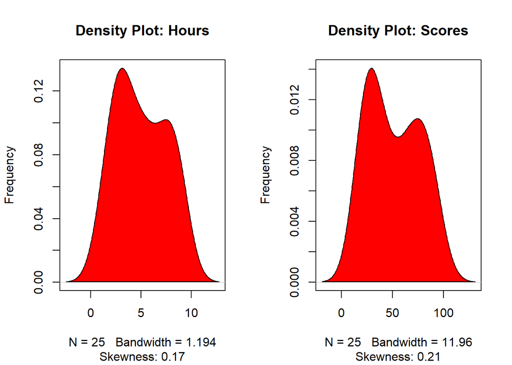

```r
# Density Plot

par(mfrow = c(1,2))
plot(density(Hours_data$Hours), main="Density Plot: Hours", ylab="Frequency", sub=paste("Skewness:", round(e1071::skewness(Hours_data$Hours), 2)))
polygon(density(Hours_data$Hours), col="red")
plot(density(Hours_data$Scores), main="Density Plot: Scores", ylab="Frequency", sub=paste("Skewness:", round(e1071::skewness(Hours_data$Scores), 2)))
polygon(density(Hours_data$Scores), col="red")
```

```r
# Correlation

cor(Hours_data$Hours , Hours_data$Scores)
```

```
## [1] 0.9761907
```

Now , we will split the dataset into training set and test set .

```r
# Splitting the dataset into Training set and Test set

set.seed(123)
split <- sample.split(Hours_data$Scores , SplitRatio = 0.75)
training_set <- subset(Hours_data , split == TRUE)
training_set
```

```
##    Hours Scores
## 1    2.5     21
## 2    5.1     47
## 3    3.2     27
## 4    8.5     75
## 6    1.5     20
## 7    9.2     88
## 9    8.3     81
## 10   2.7     25
## 12   5.9     62
## 13   4.5     41
## 14   3.3     42
## 15   1.1     17
## 17   2.5     30
## 18   1.9     24
## 19   6.1     67
## 22   4.8     54
## 23   3.8     35
## 25   7.8     86
```

```r
test_set <- subset(Hours_data , split == FALSE)
test_set
```

```
##    Hours Scores
## 5    3.5     30
## 8    5.5     60
## 11   7.7     85
## 16   8.9     95
## 20   7.4     69
## 21   2.7     30
## 24   6.9     76
```

Here , we will fit the linear regression model on training set.

```r
# Fitting Simple Linear Regression to a training set

regressor <- lm(formula = Scores ~ Hours , data = training_set)
regressor
```

```
##
## Call:
## lm(formula = Scores ~ Hours, data = training_set)
##
## Coefficients:
## (Intercept)        Hours
##       4.047        9.301
```

```r
summary(regressor)
```

```
##
## Call:
## lm(formula = Scores ~ Hours, data = training_set)
##
## Residuals:
##     Min      1Q  Median      3Q     Max
## -8.1019 -4.4571  0.8804  2.9905  9.4085
##
## Coefficients:
##             Estimate Std. Error t value Pr(>|t|)
## (Intercept)   4.0465     2.7108   1.493    0.155
## Hours         9.3006     0.5194  17.908 5.22e-12 ***
## ---
## Signif. codes:  0 '***' 0.001 '**' 0.01 '*' 0.05 '.' 0.1 ' ' 1
##
## Residual standard error: 5.457 on 16 degrees of freedom
## Multiple R-squared:  0.9525, Adjusted R-squared:  0.9495
## F-statistic: 320.7 on 1 and 16 DF,  p-value: 5.219e-12
```

We will predict the new values of test set.

```r
# Predicting the test set results

y_pred <- predict(regressor , newdata = test_set)
y_pred
```

```
##        5        8       11       16       20       21       24
## 36.59875 55.20002 75.66141 86.82217 72.87122 29.15824 68.22091
```

Now, we will visualize the training set and test set results.

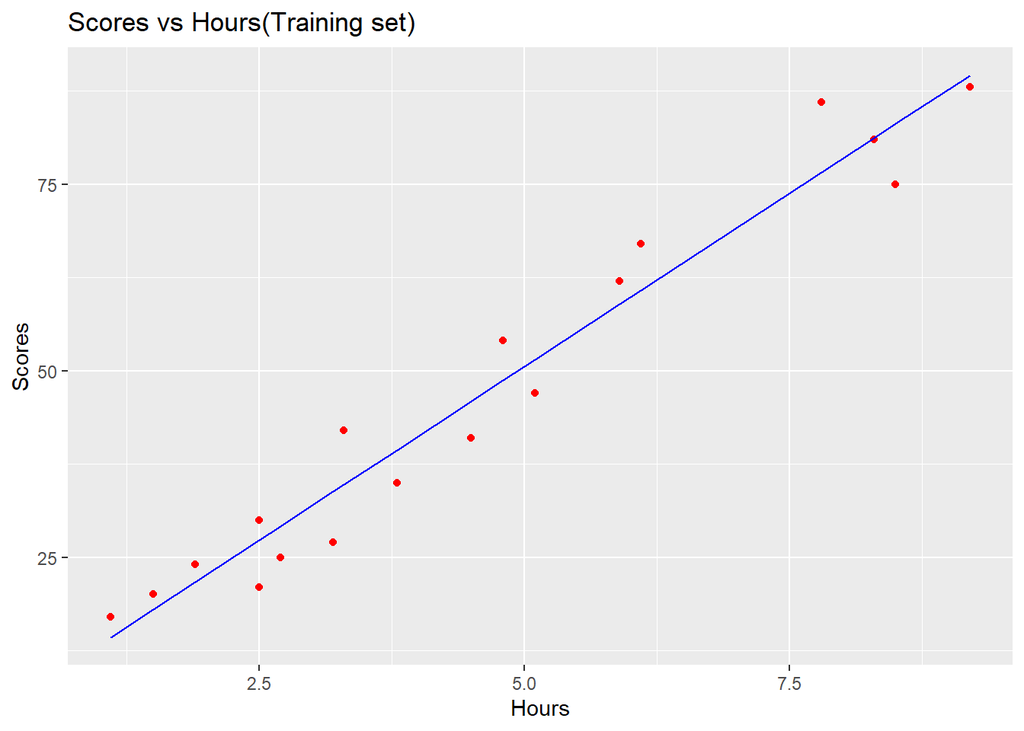

```r
# Visualizing the training set results

ggplot()+
  geom_point(aes(x = training_set$Hours , y = training_set$Scores) ,
             colour = 'red') +
  geom_line(aes(x = training_set$Hours , y =  predict(regressor , newdata = training_set)),
            colour = 'blue') +
  ggtitle('Scores vs Hours(Training set)')+
  xlab('Hours')+
  ylab('Scores')
```

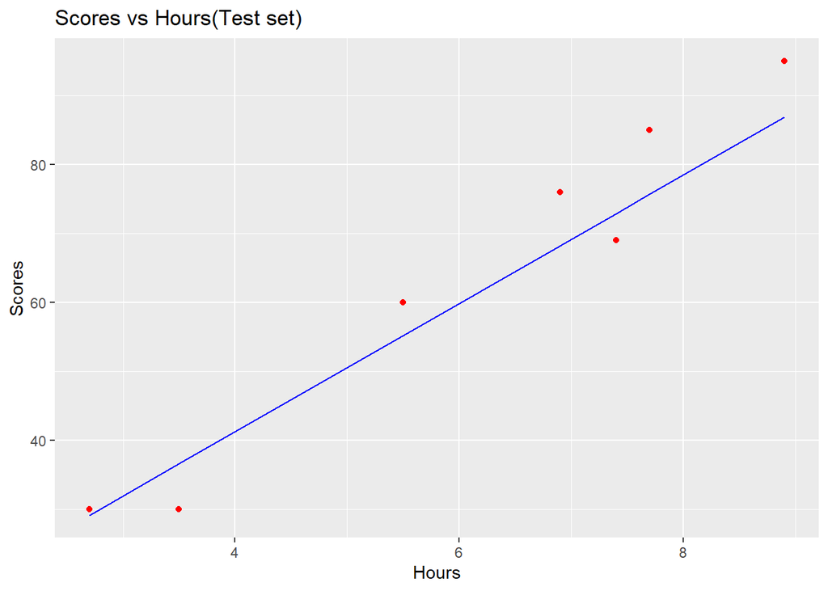

```r
# Visualizing the test set results

ggplot()+
  geom_point(aes(x = test_set$Hours , y = test_set$Scores) ,
             colour = 'red') +
  geom_line(aes(x = test_set$Hours , y =  predict(regressor , newdata = test_set)),
            colour = 'blue') +
  ggtitle('Scores vs Hours(Test set)')+
  xlab('Hours')+
  ylab('Scores')
```

Finally , we will predict the score if a student studies for 9.25 hrs/day.

```r
# Predicting the value

predict(regressor,data.frame(Hours = 9.25 , Scores = " "))
```

```
##        1
## 90.07739
```